# MovieLens Report Project

Ernesto José Hernández Navarro

2024-03-25

# Introduction

Currently Machine Learning, one of the disciplines of artificial intelligence, has become one of the most important tools for public and private companies, in sectors such as health, economy, sports, traffic and movies, which is the case we are going to be analyzing this document.

Netflix organized a contest for a team that could create a movie recommendation system in 2006. This algorithm developed by BellKor’s Pragmtic Chaos team in 2009 served as a reference for companies like Amazon and offer their customers more precisely the products that they have the most propensity to buy.

The goal of this project is to use the MovieLens dataset (which has 10 million ratings), R and RStudio, to achieve a root mean square error (RMSE) less than 0.86490. Due to the large amount of information the edX team has made available the code to split the data.

To help understand the data set, a data exploration will be carried out. For the algorithm tests, the information will be divided into a training and test set in order to validate the work done on the final model, the limitations and possible future potential.

# Data exploration

The data from edX data.frame has 9,000,055 rows and 6 columns, with ratings given by a total of 69,878 unique users, with a total of 10,677 unique movies. The data has structure and does not has nulls:

```
##    userId   movieId    rating timestamp     title    genres
##         0         0         0         0         0         0
```

| title | Count_Rating |
| --- | --- |
| Pulp Fiction (1994) | 31362 |
| Forrest Gump (1994) | 31079 |
| Silence of the Lambs, The (1991) | 30382 |
| Jurassic Park (1993) | 29360 |
| Shawshank Redemption, The (1994) | 28015 |
| Braveheart (1995) | 26212 |
| Fugitive, The (1993) | 25998 |
| Terminator 2: Judgment Day (1991) | 25984 |
| Star Wars: Episode IV - A New Hope (a.k.a. Star Wars) (1977) | 25672 |
| Apollo 13 (1995) | 24284 |

The rating most used by users is 4 representing the 28.76% of the total ratings, the minimum is 0.5, the maximum is 5. The integer rates were 7,156,885 which represents the 79.5% and the decimal ratings were 1,843,170 representing the 20.5%.

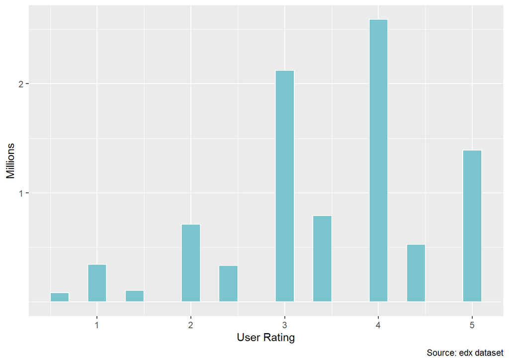

Ratings distribution

## Movies

As we know, not all the users rates the received service, and in this case, the watched movie is not always rated, some are more rated than others, and 126 movies where rated with once. So, there is a bias that has to be consider on the training algorithm.

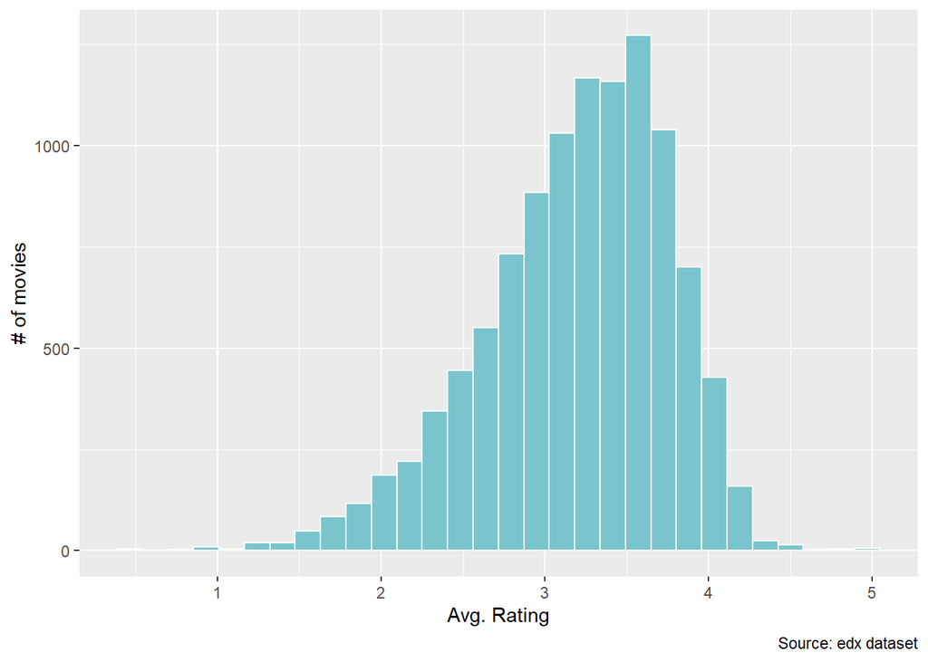

Distribution of rated movies in average

## Users

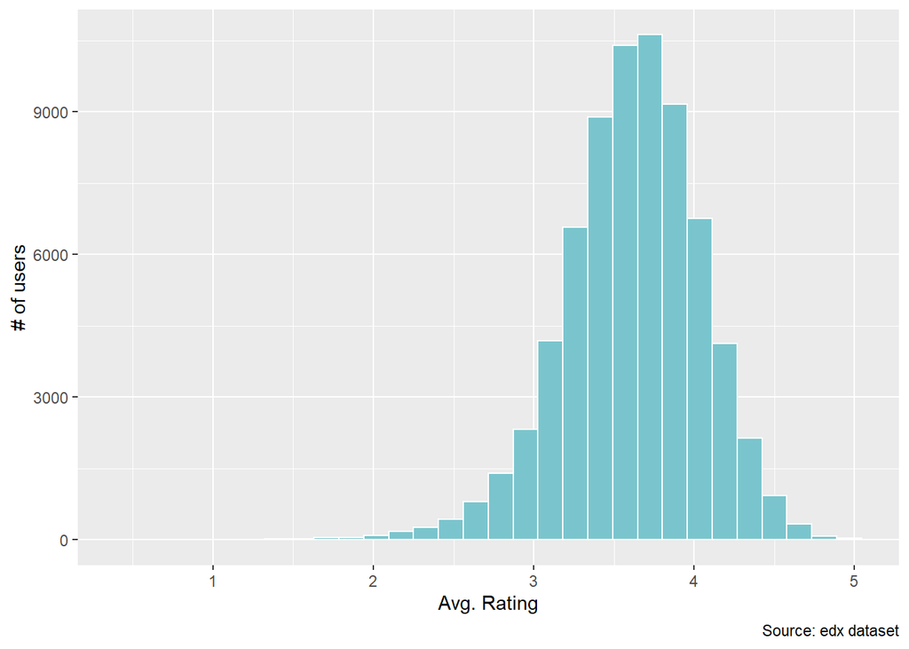

Distribution of users by Avg. Rating

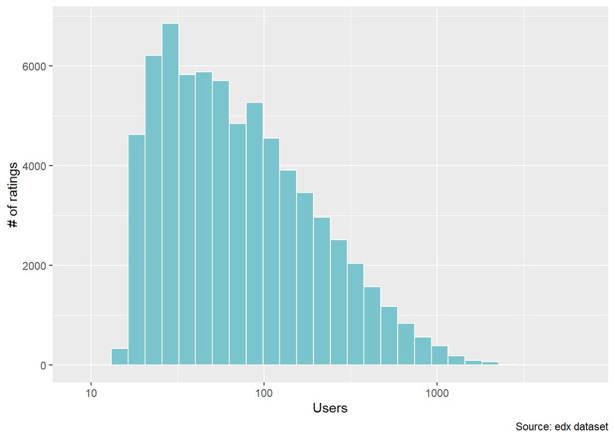

# of ratings by user

## Genre

Movies not always has one genre, so, in the edx data set we can see that the field “genre” assigns several genres and separates it with the symbol “|”, and for our exploration the first one will be take. In the following table we can see that some genres have better ratings and a greater number of ratings:

| genres | count | rating |
| --- | --- | --- |
| Drama | 3910127 | 3.67 |
| Comedy | 3540930 | 3.44 |
| Action | 2560545 | 3.42 |
| Thriller | 2325899 | 3.51 |
| Adventure | 1908892 | 3.49 |
| Romance | 1712100 | 3.55 |
| Sci-Fi | 1341183 | 3.40 |
| Crime | 1327715 | 3.67 |
| Fantasy | 925637 | 3.50 |
| Children | 737994 | 3.42 |
| Horror | 691485 | 3.27 |
| Mystery | 568332 | 3.68 |
| War | 511147 | 3.78 |
| Animation | 467168 | 3.60 |
| Musical | 433080 | 3.56 |
| Western | 189394 | 3.56 |
| Film-Noir | 118541 | 4.01 |
| Documentary | 93066 | 3.78 |
| IMAX | 8181 | 3.77 |
| (no genres listed) | 7 | 3.64 |

Drama and Comedy genre have clearly the most quantity of rates, Documentary and IMAX are the lowest rated. Also there are seven that don’t have a genre.

## Title

In the data set the column “Title” includes the release year of the movie as we can see in the following table:

| title | n |
| --- | --- |
| Pulp Fiction (1994) | 31362 |
| Forrest Gump (1994) | 31079 |
| Silence of the Lambs, The (1991) | 30382 |
| Jurassic Park (1993) | 29360 |
| Shawshank Redemption, The (1994) | 28015 |
| Braveheart (1995) | 26212 |
| Fugitive, The (1993) | 25998 |
| Terminator 2: Judgment Day (1991) | 25984 |
| Star Wars: Episode IV - A New Hope (a.k.a. Star Wars) (1977) | 25672 |
| Apollo 13 (1995) | 24284 |

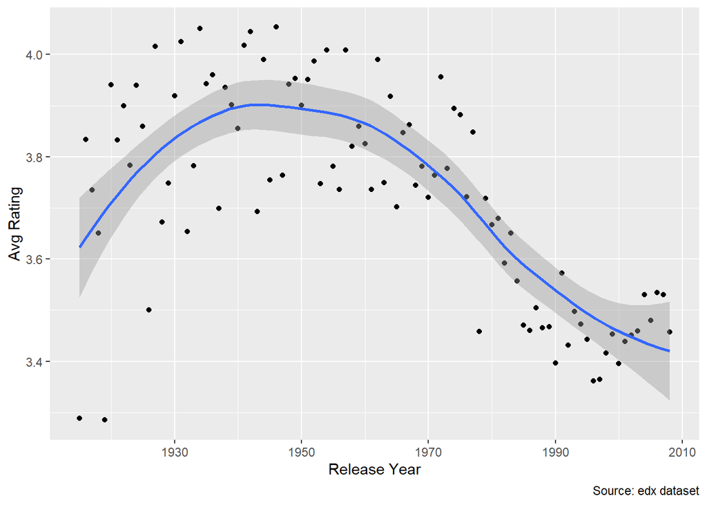

Plot with year of release:

[figure not shown]

## Methods

[output not shown]

As mentioned at the introduction our goal is to reach a RMSE less than 0.86490, to do it the edx dataset needs to be split in two parts, the training set and the test set. This together with cross-validation methods allows to prevent over-training.

Doing the same steps learned from professor Irizarry courses the data will be partitioned, 80% for training and 20% for testing using the libraries “caret”, “tydiverse” and “dplyr”.

### Error loss

The RMSE is like the standard deviation of the residual predictors. The RMSE represent the error loss between the predicted ratings from applying the algorithm and actual ratings in the test set. The formula shown below, $y_{u,i}$ is defined as the actual rating provided by a user $u$ for a movie $i$, $\hat{y}_{u,i}$ is the predicted rating for the same, and N is the total number of user/movie combinations.

$$RMSE =
\sqrt{\frac{1}{N}\sum_{u,i}\left(\hat{y}_{u,i}-y_{u,i}\right)^2}$$

### Developing the algorithm

The goal set for this project is to achieve a RMSE equal or less than 0.86490, then it will be about reaching the goal step by step. We need to the fit the model with this formula:

$$Y_{u,i}=\mu+\epsilon_{u,i}$$

The common method is to use the rating mean of every user on movies.

$$Y{u,i} = \mu$$

```r
mu_hat <- mean(train_set$rating)
RMSE(test_set$rating, mu_hat)
```

```
## [1] 1.059951
```

And any number will be higher than $\hat{\mu}$ mean as we can see below

```r
predictions <- rep(2.5, nrow(test_set))
RMSE(test_set$rating, predictions)
```

```
## [1] 1.465849
```

#### Movie effect

Due to the large dataset for this project a linear regression would take several time, a better option to work with is the least square estimate of the movie effect $\hat{b}_i$, it can be take from the average of $Y_{u,i}-\hat{\mu}$ in every movie $i$. The following formula was used to get the movie effect:

$$Y_{u,i}=\mu+b_i+\epsilon_{u,i}$$

And we can see the effect of the movies with the following plot:

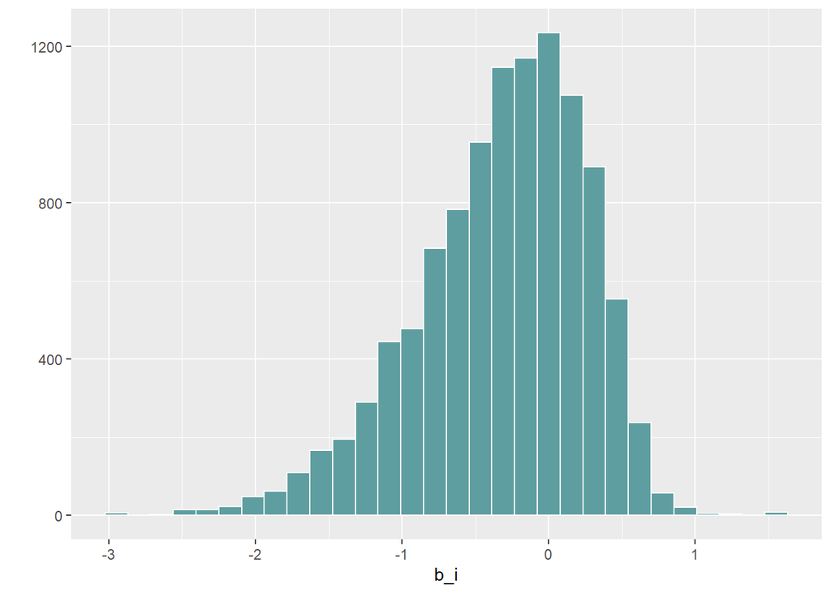

Distribution movie effect

The RMSE is lowest than the mean and it was a good improve, as it was shown in data exploration some movies get more rated than others, we still need improve more the result to get our objective.

```r
# Predict ratings adjusting for movie effects
predicted_ratings<-mu_hat+test_set%>%
  left_join(movie_avg, by = "movieId") %>%
  pull(b_i)

# Calculate RMSE based on movie effects model
model_1_rmse<-RMSE(test_set$rating, predicted_ratings)

#Save result and show difference between objective
df_results<-bind_rows(df_results,
                      data.frame(Method = "Movie  Effect", RMSE = as.character(round(model_1_rmse,5)),
                                 Difference = as.character(round(model_1_rmse,5)-objective_rmse)))

df_results %>% knitr::kable()
```

| Method | RMSE | Difference |
| --- | --- | --- |
| Objective | 0.8649 | - |
| Movie Effect | 0.94367 | 0.07877 |

#### User effect

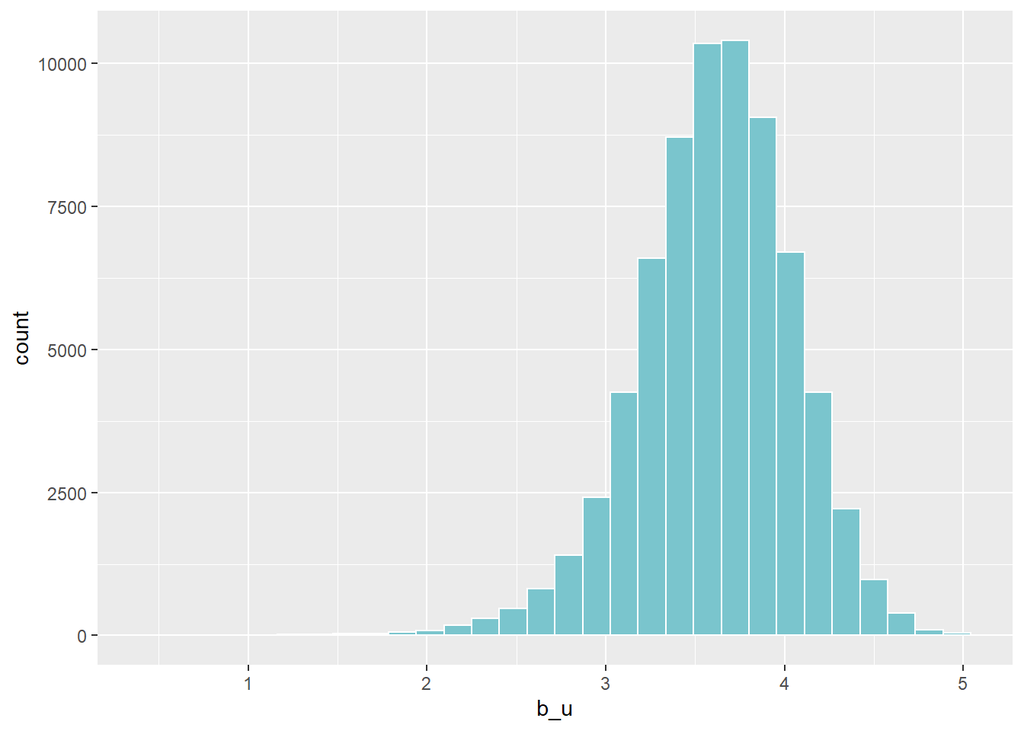

Distribution user effect

| Method | RMSE | Difference |
| --- | --- | --- |
| Objective | 0.8649 | - |
| Movie Effect | 0.94367 | 0.07877 |
| Movie + User Effect | 0.86561 | 0.00071 |

#### Gender effect

The movies acclaimed by critics then to be more rated by users thats why we saw an improve using movies and users, but this happens with the genre too. The table below shows the results.

| Method | RMSE | Difference |
| --- | --- | --- |
| Objective | 0.8649 | - |
| Movie Effect | 0.94367 | 0.07877 |
| Movie + User Effect | 0.86561 | 0.00071 |
| Movie, User, Genre Effect | 0.86526 | 0.00036 |

#### Year effect

| Method | RMSE | Difference |
| --- | --- | --- |
| Objective | 0.8649 | - |
| Movie Effect | 0.94367 | 0.07877 |
| Movie + User Effect | 0.86561 | 0.00071 |
| Movie, User, Genre Effect | 0.86526 | 0.00036 |
| Movie, User, Genre, Year Effect | 0.86509 | 0.00019 |

#### Date Review effect

Our final bias is the date review, this column is a exact date with hours, to get a better approximation it was rounded to week.

| Method | RMSE | Difference |
| --- | --- | --- |
| Objective | 0.8649 | - |
| Movie Effect | 0.94367 | 0.07877 |
| Movie + User Effect | 0.86561 | 0.00071 |
| Movie, User, Genre Effect | 0.86526 | 0.00036 |
| Movie, User, Genre, Year Effect | 0.86509 | 0.00019 |
| Movie, User, Genre, Year, Date Review Effect | 0.8649 | 0 |

This leads to the RMSE objective, but, can it be better?

#### Regularization effect

Answering the last question, yes, we can improve the last result with regularization. The following plot shows the RMSE tested for every $\lambda$ value tested. The optimal parameter is 4.7 which minimized the RMSE to 0.86462.

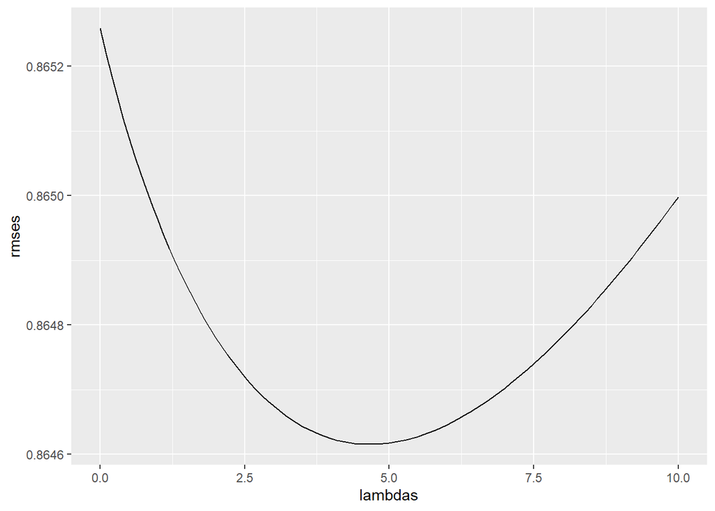

Selecting best lambda

| Method | RMSE | Difference |
| --- | --- | --- |
| Objective | 0.8649 | - |
| Movie Effect | 0.94367 | 0.07877 |
| Movie + User Effect | 0.86561 | 0.00071 |
| Movie, User, Genre Effect | 0.86526 | 0.00036 |
| Movie, User, Genre, Year Effect | 0.86509 | 0.00019 |
| Movie, User, Genre, Year, Date Review Effect | 0.8649 | 0 |
| Regularized Movie, User, Genre, Year, Date Review Effect | 0.86462 | -0.00028 |

## Final testing

With our algorithm defined and using using the training set and the test set to validate the RMSE, for our final step, the date review was modify to enhance the running time. The final result for the RMSE is 0.85621 that is less than the objective o the project:

```r
df_final_model %>% knitr::kable()
```

| Method | RMSE | Difference |
| --- | --- | --- |
| Objective | 0.8649 | - |
| Final RMSE | 0.85621 | -0.00869 |

# Conclusions

Analyzing the MovieLens dataset we found bias that were reduce to a RMSE lower than the objective, this was thanks to regularization to.

We could improve this result using matrix factorization, singular value descomposition (SVD) and principal component analysis (PCA). It quantify residuals within this error loss based on patterns observed between groups of movies or groups of users such that the residual error in predictions can be further reduced.

# Reference

Irizarry, Rafael A. 2020. Introduction to Data Science: Data Analysis and Prediction Algorithms

with R. CRC Press.

http://rafalab.dfci.harvard.edu/dsbook/